# Distribution Modelling

Nima Ramezani Taghiabadi

11/02/2019

## Introduction:

In machine learning, we often use a model to describe the process that results in the observed data. We may use a classifier like logistic regression or random forest to classify whether customers may cancel a subscription from a service (known as churn modelling) or we may use a regression model to predict the revenue that will be generated for a company depending on the amount of fund spend on advertising. Each model contains its own set of parameters that ultimately defines what the model looks like. We may have various distributions for the output label depending on the underlying process that generates it. Ignoring the distribution of the output variables in machine learning, can lead to poor predictions. For example. if the distribution of the label is exponential, we may observe outliers which is expected for exponential distribution. If we use a regression model which minimizes mean squared error, those outlier values can ruin the model prediction for the majority of data just because we are trying to fit those outliers. Thus, choice of the objective (loss function) is important when we train the model. In this case, for examle median absolute error between the predicted and actual value could be a better loss rather than mean absolute or mean squared error.

## Machine Learning with non-linear conversion of the output:

As an example consider the total daily amount of cash people withdraw from an ATM machine. Looking at the data, you may find a special kind of distribution which may look like gaussian, however you may also see that it cannot always fit to gaussian very well because especially where the mean is low, Gaussian distribution could generate negative values, while we do have negative values in total daily withdrawal amounts. So, which distribution is best describing the behaviour of this data? To answer this question, we should have a look at the underlying process that generates our output variable. Total daily withdrawal from an ATM is the sum of multiple individual cash withdrawals from individuals. Now, if we see each withdrawal as a sum of denominations of say $20 and $50 cash notes, we can model the count of notes in each withdrawal separately. If we have more detailed data in denomination transaction level, we can fit various possible distributions to each transaction to find which one fits best, but we consider a case where such data is not available. In this case, we will need to assume a distribution for each transaction and build a combined distribution which best describes the process. For example let’s assume count of each denomination to be of prime beta distribution and counts of customer arrivals in a day to have a Poisson distribution. Having this assumption, the probability distribution function(pdf) of the combined distribution for total daily withdrawal is very complicated and not expressable as closed form, however, we can estimate its mean(first moment) from parameters of three distributions we assumed:

$$\overline{x} = \lambda . \big ( \frac{20 \alpha_{20}}{\beta_{20} - 1} + \frac{50 \alpha_{50}}{\beta_{50} - 1} \big )$$
where $\lambda$ is the customer arrival rate, $\alpha_{20}$, $\beta_{20}$ are parameters for the distribution of $20 notes and similarly, $\alpha_{50}$, $\beta_{50}$ for $50 notes. Now, one can build a regression model, or neural network with 5 outputs, one for each parameter and minimize the mean squared error. We may get a better result now comparing to when regressing the output variable directly. Note that this is not what we refer to as likelihood maximization. However, if the distribution of the observed data is too complicated, this could be a better way to train the model.

## Likelihood Maximization:

You may have faced with situations where the output label is highly biased or unbalanced (in classification) or in regression, you may observe outliers or unspecific values. For example there might exist cases where you don’t have the label value but can only know the it is greater than or lower than a certain value. This is especially the case in sticky project where you want to include samples of customers who have not churned until the current time. Using classic Machine Learning models, you will need to remove lots of training data samples (and unforetunately, the most recent ones) due to uncertainty of the label. Likelihood Maximization and distribution modelling is a way to adress this problem where you include all data in training which may lead to better accuracy rates.

Likelihood Maximization or Maximum Likelihood Estimation is a method that determines values for the parameters of a model so that the likelihood of the observed data with respect to the assumed distribution is maximized. Distributions are indexed by their underlying parameters. Thus, as long as we know the parameter, we know the entire distribution. For instance, for Normal distributions $N(μ,σ)$, if we know $μ$ and $σ$, the entire distribution is determined. In machine learning with Likelihood Maximization, we try to regress parameters of the distribution underlying the observed data rather than its value directly. For normal (Gaussian) distributions, [Linear regression with MSE as loss, returns the same result as Likelihood Maximization](https://www.cs.princeton.edu/courses/archive/fall18/cos324/files/mle-regression.pdf).

Now, consider that the observed distribution of our label data may not necessariy be normal. In this case, we first have to decide which model we think best describes the process of generating the data. This part is very important. At the very least, we should have a good idea about which model to use.

For example, in exponential distributions Exp(λ), as long as we know the value of λ, we know the entire distribution. Because parameters in the parametric distributions determine the entire distribution, finding these parameters is very important in practice. There are many approaches of finding parameters; here we will introduce the most famous and perhaps most important one–the [maximum likelihood estimator](http://faculty.washington.edu/yenchic/17Sp_403/Lec3_MLE_MSE.pdf) (MLE).

## ML with Likelihood Maximization for exponential distribution:

#### Predicting Time to Event:

Consider an eventlog which describes the life a set of cases from when they are started until the current time and assume our output label is time until a particular event. To obtain training data, we first split the data by a random time and take historic samples of the past data and track the case status until the split time which we assume is the current time for a experiment. We used a sample dataset which has Time to Churn as output label. Look at the histogram of the output label:

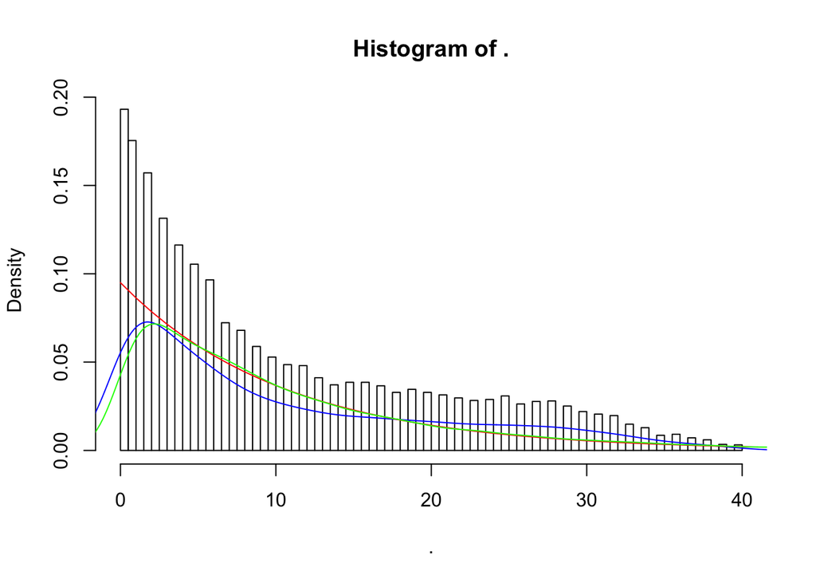

```r
c(X_train, y_train, X_test, y_test) %<-% read_kaggle_data()
y_train %>% hist(breaks = 100, prob = T)
y_train %>% density %>% lines(col="blue")
a = 1.0/mean(y_train); x = 0:max(y_test); lines(x, a*exp(-a*x), col="red")
rexp(length(y_train), rate = a) %>% density %>% lines(col="green")
```

### Simple linear regression

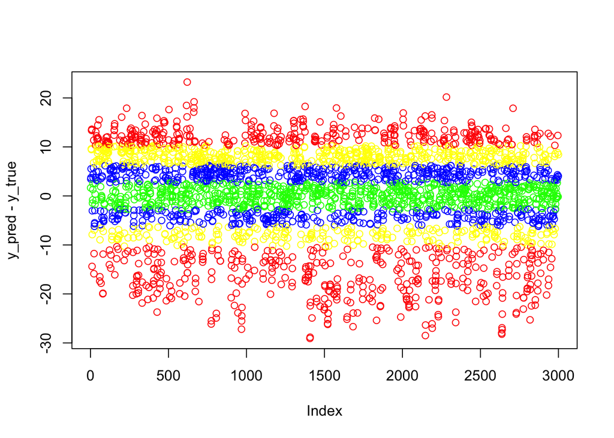

```r
model = lm(y_train ~ X_train)
y_pred = model$coefficients %>% predict.lm(X_test)
loss.plot(y_pred, y_test)
```

```r
loss.summary(y_pred, y_test)
```

```
##
##  Summary of loss:
##
## Mean Absolute Error   :  7.198857
## Median Absolute Error :  6.21264
## Error Distribution    :
## 569  ( 19 %)  of errors are less than  2
## 1663  ( 55 %)  of errors are less than  7
## 2797  ( 93 %)  of errors are less than  17
```

The error plot does not look really good.

### Regression with likelihood maximization for exponential distribution

```r
model = lm.exp(X_train, y_train)
```

```
## Iter:  1 --> loss value:  4.005961 --> improvement:  1.952686 --> step size:  1
## Iter:  2 --> loss value:  3.514553 --> improvement:  0.4914084 --> step size:  1
## Iter:  3 --> loss value:  3.495838 --> improvement:  0.01871527 --> step size:  0.5
## Iter:  4 --> loss value:  3.315778 --> improvement:  0.1800591 --> step size:  0.5
## Iter:  5 --> loss value:  3.284914 --> improvement:  0.03086447 --> step size:  1
## Iter:  6 --> loss value:  3.264786 --> improvement:  0.02012805 --> step size:  0.25
## Iter:  7 --> loss value:  3.261625 --> improvement:  0.003160939 --> step size:  0.5
## Iter:  8 --> loss value:  3.258907 --> improvement:  0.002717807 --> step size:  0.25
## Iter:  9 --> loss value:  3.257961 --> improvement:  0.0009460548 --> step size:  0.5
## Iter:  10 --> loss value:  3.257585 --> improvement:  0.0003757157 --> step size:  1
## Iter:  11 --> loss value:  3.257584 --> improvement:  1.592836e-06 --> step size:  0.5
```

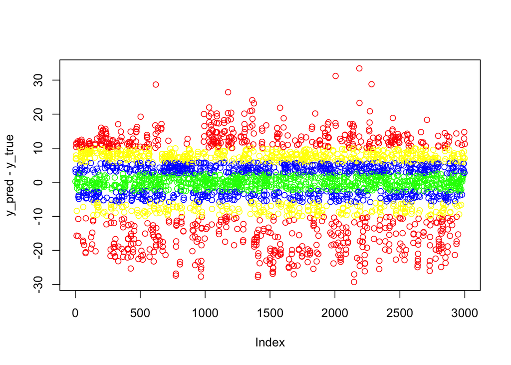

```r
y_pred = model %>% predict.lm.exp(X_test) %>% convert.exp.landa
loss.plot(y_pred, y_test)
```

```r
loss.summary(y_pred, y_test)
```

```
##
##  Summary of loss:
##
## Mean Absolute Error   :  7.17112
## Median Absolute Error :  5.812987
## Error Distribution    :
## 611  ( 20 %)  of errors are less than  2
## 1732  ( 58 %)  of errors are less than  7
## 2747  ( 92 %)  of errors are less than  17
```

### Neural network with two layers with MSE as loss function

```r
model   <- build_model(inputs = dim(X_train)[2], act3 = 'linear') %>% decompile(loss = 'mse')
```

```
## Model: "sequential_1"
## ___________________________________________________________________________
## Layer (type)                     Output Shape                  Param #
## ===========================================================================
## dense_1 (Dense)                  (None, 64)                    3328
## ___________________________________________________________________________
## dropout_1 (Dropout)              (None, 64)                    0
## ___________________________________________________________________________
## dense_2 (Dense)                  (None, 32)                    2080
## ___________________________________________________________________________
## dropout_2 (Dropout)              (None, 32)                    0
## ___________________________________________________________________________
## dense_3 (Dense)                  (None, 1)                     33
## ===========================================================================
## Total params: 5,441
## Trainable params: 5,441
## Non-trainable params: 0
## ___________________________________________________________________________
```

```r
history <- model %>% defit(X = X_train, y = y_train)
```

```
## epoch: 0  loss:  135.183 validation loss: 90.5823
## epoch: 1  loss:  89.48373 validation loss: 83.31304
## epoch: 2  loss:  84.96882 validation loss: 80.13655
## epoch: 3  loss:  82.19884 validation loss: 79.44647
## epoch: 4  loss:  80.14243 validation loss: 78.29539
## epoch: 5  loss:  79.88515 validation loss: 77.52061
## epoch: 6  loss:  78.27064 validation loss: 76.04641
## epoch: 7  loss:  76.88364 validation loss: 75.35586
## epoch: 8  loss:  76.89186 validation loss: 75.39131
## epoch: 9  loss:  75.2821 validation loss: 74.94724
## epoch: 10  loss:  74.78506 validation loss: 74.51476
## epoch: 11  loss:  74.94675 validation loss: 73.83795
## epoch: 12  loss:  74.6323 validation loss: 74.0058
## epoch: 13  loss:  74.32801 validation loss: 73.84767
## epoch: 14  loss:  74.3668 validation loss: 73.62521
## epoch: 15  loss:  73.16894 validation loss: 73.27633
## epoch: 16  loss:  73.56477 validation loss: 72.70872
## epoch: 17  loss:  72.6174 validation loss: 72.80599
## epoch: 18  loss:  72.18618 validation loss: 72.55307
## epoch: 19  loss:  72.72778 validation loss: 72.1344
## epoch: 20  loss:  72.17877 validation loss: 72.22436
## epoch: 21  loss:  71.74083 validation loss: 71.84993
## epoch: 22  loss:  71.56583 validation loss: 71.86759
## epoch: 23  loss:  71.52808 validation loss: 71.47184
## epoch: 24  loss:  71.39845 validation loss: 71.45622
## epoch: 25  loss:  70.30098 validation loss: 71.02612
## epoch: 26  loss:  70.82004 validation loss: 70.63944
## epoch: 27  loss:  70.32805 validation loss: 70.62105
## epoch: 28  loss:  71.14577 validation loss: 71.12523
## epoch: 29  loss:  70.56736 validation loss: 71.03924
```

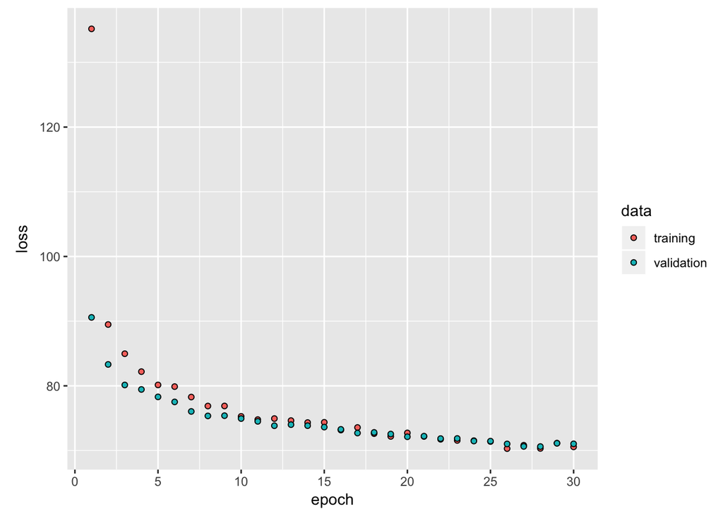

```r
plot(history, metrics = "loss", smooth = FALSE)
```

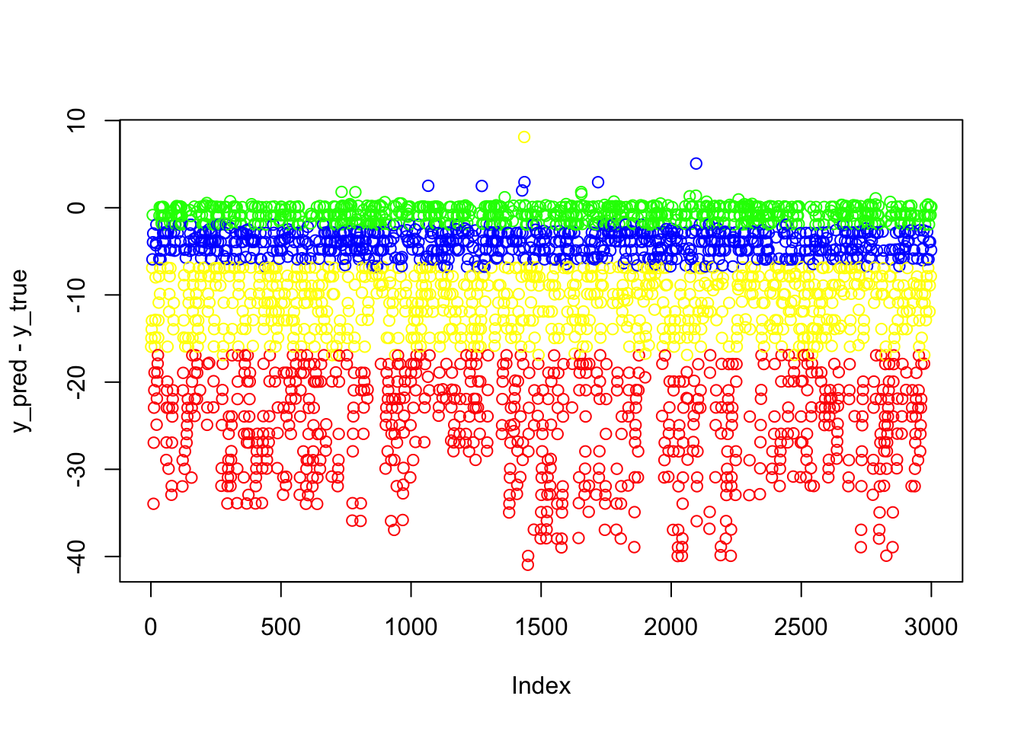

```r
y_pred = convert.exp.landa(model$predict(X_test))
loss.plot(y_pred, y_test)
```

```r
loss.summary(y_pred, y_test)
```

```
##
##  Summary of loss:
##
## Mean Absolute Error   :  10.25629
## Median Absolute Error :  6.782822
## Error Distribution    :
## 777  ( 26 %)  of errors are less than  2
## 1605  ( 54 %)  of errors are less than  7
## 2289  ( 76 %)  of errors are less than  17
```

### Neural network with two layers with exponential log-likelihood as loss function

```r
model   <- build_model(inputs = dim(X_train)[2], act3 = 'sigmoid') %>% decompile(loss = loss.exp.landa)
```

```
## Model: "sequential_2"
## ___________________________________________________________________________
## Layer (type)                     Output Shape                  Param #
## ===========================================================================
## dense_4 (Dense)                  (None, 64)                    3328
## ___________________________________________________________________________
## dropout_3 (Dropout)              (None, 64)                    0
## ___________________________________________________________________________
## dense_5 (Dense)                  (None, 32)                    2080
## ___________________________________________________________________________
## dropout_4 (Dropout)              (None, 32)                    0
## ___________________________________________________________________________
## dense_6 (Dense)                  (None, 1)                     33
## ===========================================================================
## Total params: 5,441
## Trainable params: 5,441
## Non-trainable params: 0
## ___________________________________________________________________________
```

```r
history <- model %>% defit(X = X_train, y = y_train)
```

```
## epoch: 0  loss:  3.871698 validation loss: 3.34832
## epoch: 1  loss:  3.402579 validation loss: 3.295312
## epoch: 2  loss:  3.327972 validation loss: 3.282191
## epoch: 3  loss:  3.290278 validation loss: 3.262288
## epoch: 4  loss:  3.277046 validation loss: 3.242722
## epoch: 5  loss:  3.25739 validation loss: 3.241379
## epoch: 6  loss:  3.248076 validation loss: 3.234165
## epoch: 7  loss:  3.238064 validation loss: 3.227507
## epoch: 8  loss:  3.226381 validation loss: 3.230077
## epoch: 9  loss:  3.225082 validation loss: 3.223327
## epoch: 10  loss:  3.218891 validation loss: 3.231232
## epoch: 11  loss:  3.218268 validation loss: 3.227677
## epoch: 12  loss:  3.210025 validation loss: 3.220055
## epoch: 13  loss:  3.205766 validation loss: 3.220152
## epoch: 14  loss:  3.202066 validation loss: 3.210783
## epoch: 15  loss:  3.199493 validation loss: 3.215474
## epoch: 16  loss:  3.193529 validation loss: 3.212052
## epoch: 17  loss:  3.197137 validation loss: 3.22287
## epoch: 18  loss:  3.191506 validation loss: 3.214056
## epoch: 19  loss:  3.189557 validation loss: 3.213453
## epoch: 20  loss:  3.188401 validation loss: 3.211038
## epoch: 21  loss:  3.189507 validation loss: 3.205405
## epoch: 22  loss:  3.179225 validation loss: 3.207101
## epoch: 23  loss:  3.18302 validation loss: 3.213863
## epoch: 24  loss:  3.178896 validation loss: 3.206576
## epoch: 25  loss:  3.176168 validation loss: 3.204805
## epoch: 26  loss:  3.177651 validation loss: 3.200948
## epoch: 27  loss:  3.171395 validation loss: 3.201168
## epoch: 28  loss:  3.172714 validation loss: 3.203266
## epoch: 29  loss:  3.17304 validation loss: 3.204795
```

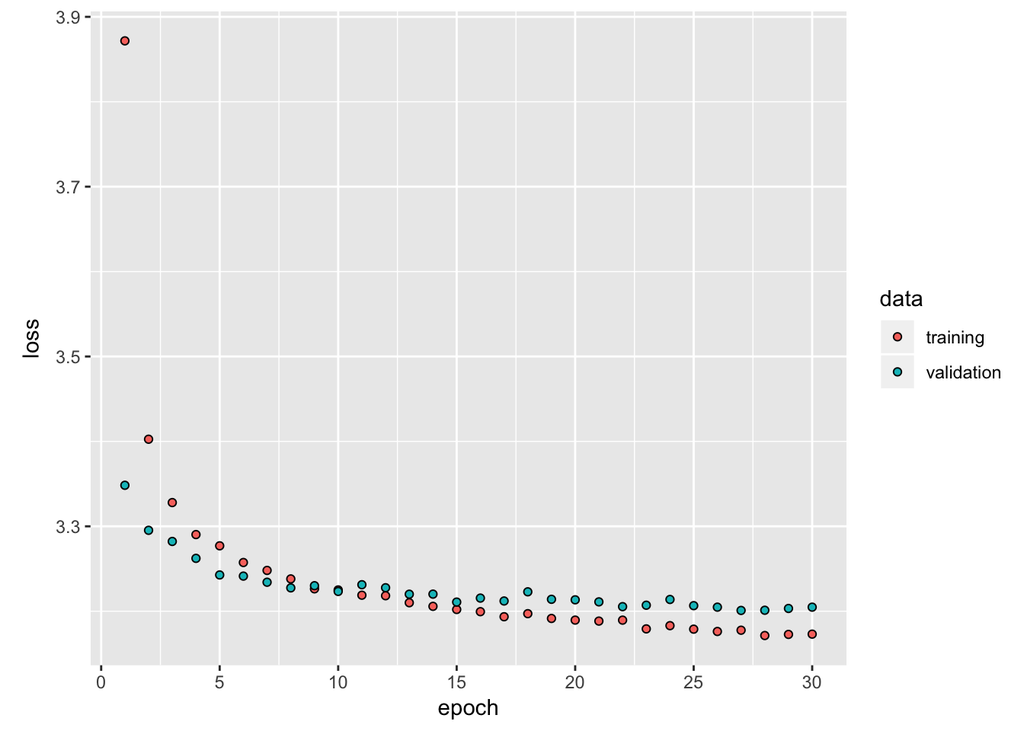

```r
plot(history, metrics = "loss", smooth = FALSE)
```

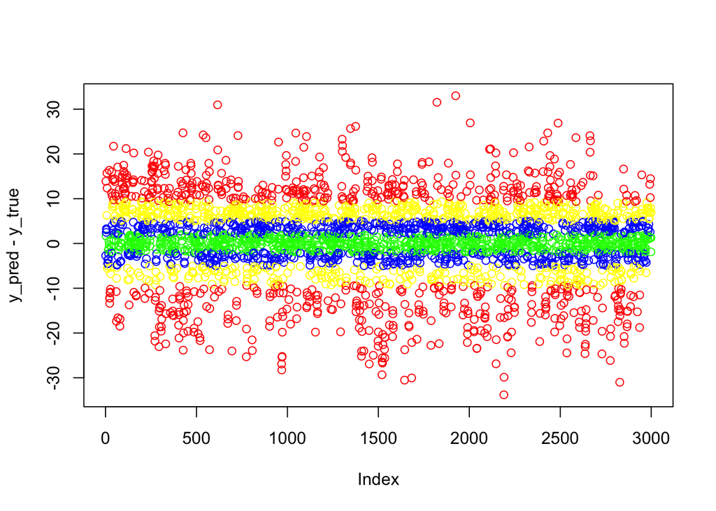

```r
y_pred = convert.exp.landa(model$predict(X_test))
loss.plot(y_pred, y_test)
```

```r
loss.summary(y_pred, y_test)
```

```
##
##  Summary of loss:
##
## Mean Absolute Error   :  6.519917
## Median Absolute Error :  4.994181
## Error Distribution    :
## 749  ( 25 %)  of errors are less than  2
## 1894  ( 63 %)  of errors are less than  7
## 2810  ( 94 %)  of errors are less than  17
```